# Meteorological Conditions of Chosen Storm - Eastern Scheldt

## Introduction

This document plots meteorological conditions of a chosen storm event for the Eastern Scheldt, converting the MATLAB script `master6.m` to Python. The analysis:

1. Loads barrier closure dates and tide gauge data from previous analyses
2. Calculates surge component (WLP - TIP)
3. Loads GTSM reanalysis surge data (spatial surge patterns)
4. Loads ERA5 meteorological reanalysis data (pressure and wind fields)
5. Creates multiple visualizations:
   - Water level and surge time series (zoomed to closure event)
   - GTSM surge maps at 6 time steps around the closure
   - ERA5 meteorological maps (pressure + wind vectors) at 6 time steps

This provides a comprehensive view of the meteorological conditions that led to a specific barrier closure.

## Setup and Configuration

```python
import numpy as np
import pandas as pd
import pickle
import matplotlib.pyplot as plt
from datetime import datetime, timedelta
import xarray as xr
import os

# Configuration
e = 11  # Closure event index (0-indexed)
tint = 6  # Time interval for GTSM plots (hours)
tint_met = 12  # Time interval for meteorological plots (hours)
gtsm_start_date = datetime(1992, 11, 11, 0, 0, 0)  # Start date for GTSM plots
met_start_date = datetime(1992, 11, 10, 18, 0, 0)  # Start date for meteorological plots
output_dir = 'output'
data_dir = '../2_DATA'

# Spatial bounds
xb_gtsm = [-10, 10]  # GTSM longitude bounds
yb_gtsm = [45, 60]   # GTSM latitude bounds
xb_met = [-30, 15]   # ERA5 longitude bounds
yb_met = [40, 70]    # ERA5 latitude bounds

os.makedirs(output_dir, exist_ok=True)

print(f"Analysis configuration:")
print(f"  Closure event index: {e}")
print(f"  GTSM time interval: {tint} hours")
print(f"  GTSM start date: {gtsm_start_date}")
print(f"  Meteorological time interval: {tint_met} hours")
print(f"  Meteorological start date: {met_start_date}")
print(f"  Output directory: {output_dir}")
```

```
Analysis configuration:
  Closure event index: 11
  GTSM time interval: 6 hours
  GTSM start date: 1992-11-11 00:00:00
  Meteorological time interval: 12 hours
  Meteorological start date: 1992-11-10 18:00:00
  Output directory: output
```

## Load Barrier Closure and Tide Data

```python
# Load barrier closure data from master1
print("Loading barrier closure data...")
mast1_file = os.path.join(output_dir, 'mast1.pkl')
if not os.path.exists(mast1_file):
    raise FileNotFoundError(
        f"Required file {mast1_file} not found. "
        "Please run master1.qmd first to generate the required data file."
    )
with open(mast1_file, 'rb') as f:
    data1 = pickle.load(f)
    OCD = data1['OCD']  # Observed closure dates

# Load tide gauge and tidal prediction data from master3
print("Loading tide gauge and tidal prediction data...")
mast3_file = os.path.join(output_dir, 'mast3.pkl')
if not os.path.exists(mast3_file):
    raise FileNotFoundError(
        f"Required file {mast3_file} not found. "
        "Please run master1.qmd, master2.qmd, and master3.qmd first to generate the required data files."
    )
with open(mast3_file, 'rb') as f:
    data3 = pickle.load(f)
    TSP = data3['TSP']  # Time series for predictions
    TIP = data3['TIP']  # Predicted tides
    WLP = data3['WLP']  # Observed water levels

# Convert to numpy arrays if needed
OCD = np.array(OCD)
TSP = np.array(TSP)
TIP = np.array(TIP)
WLP = np.array(WLP)

# Calculate surge
SUP = WLP - TIP

# Check if event index is valid
if e >= len(OCD):
    raise ValueError(f"Event index {e} is out of range. There are {len(OCD)} closure events (indices 0-{len(OCD)-1})")

# Get the selected closure event date
ee = OCD[e]

print(f"\nData loaded:")
print(f"  Total closure dates: {len(OCD)} closures")
print(f"  Selected closure event: {e} (date: {ee})")
print(f"  Time series points: {len(TSP):,}")
```

```
Loading barrier closure data...
Loading tide gauge and tidal prediction data...

Data loaded:
  Total closure dates: 31 closures
  Selected closure event: 11 (date: 1992-11-11 00:00:00)
  Time series points: 1,998,576
```

## Load GTSM Surge Data

```python
# Load GTSM reanalysis surge data
file_in = os.path.join(data_dir, '3_CODEC_GTSM', 'reanalysis_surge_hourly_1992_11_v3.nc')
print(f"\nLoading GTSM data from: {file_in}")

ds_gtsm = xr.open_dataset(file_in)

# Extract data
TS_GT = pd.to_datetime(ds_gtsm['time'].values)
X_GT = ds_gtsm['station_x_coordinate'].values
Y_GT = ds_gtsm['station_y_coordinate'].values
SU_GT = ds_gtsm['surge'].values

# Filter to spatial bounds
mask = (X_GT >= xb_gtsm[0]) & (X_GT <= xb_gtsm[1]) & (Y_GT >= yb_gtsm[0]) & (Y_GT <= yb_gtsm[1])
X_GT = X_GT[mask]
Y_GT = Y_GT[mask]
SU_GT = SU_GT[:, mask]  # Index stations (second axis), not time (first axis)

print(f"  GTSM data loaded:")
print(f"    Time points: {len(TS_GT)}")
print(f"    Stations: {len(X_GT)}")
print(f"    Time range: {TS_GT[0]} to {TS_GT[-1]}")
```

```
Loading GTSM data from: ../2_DATA/3_CODEC_GTSM/reanalysis_surge_hourly_1992_11_v3.nc
  GTSM data loaded:
    Time points: 720
    Stations: 3873
    Time range: 1992-11-01 00:00:00 to 1992-11-30 23:00:00
```

## Load ERA5 Meteorological Data

```python
# Load ERA5 meteorological data
filein_met = os.path.join(data_dir, '4_ERA5', 'ERA5_1992_11.nc')
print(f"\nLoading ERA5 data from: {filein_met}")

ds_met = xr.open_dataset(filein_met)

# Extract data
LON = ds_met['longitude'].values
LAT = ds_met['latitude'].values
P_MET = ds_met['msl'].values  # Mean sea level pressure
U_MET = ds_met['u10'].values   # 10m u-wind component
V_MET = ds_met['v10'].values   # 10m v-wind component
TS_MET = pd.to_datetime(ds_met['valid_time'].values)

# Check and handle dimension order - ERA5 typically has (time, lat, lon) or (time, lon, lat)
# We need to ensure arrays are in (lon, lat, time) order for consistent indexing
print(f"  Original array shapes:")
print(f"    P_MET: {P_MET.shape}")
print(f"    U_MET: {U_MET.shape}")
print(f"    V_MET: {V_MET.shape}")

# Get dimension names to determine order
dims = ds_met['msl'].dims
print(f"    Dimension order: {dims}")

# Reorder to (lon, lat, time) if needed
if len(P_MET.shape) == 3:
    # Check if time dimension is first (could be 'time' or 'valid_time')
    if 'time' in dims[0].lower() or dims[0] == 'valid_time':
        # If time is first, transpose to (lon, lat, time) or (lat, lon, time)
        if dims[1] == 'latitude' and dims[2] == 'longitude':
            # (time, lat, lon) -> (lon, lat, time)
            P_MET = np.transpose(P_MET, (2, 1, 0))
            U_MET = np.transpose(U_MET, (2, 1, 0))
            V_MET = np.transpose(V_MET, (2, 1, 0))
        elif dims[1] == 'longitude' and dims[2] == 'latitude':
            # (time, lon, lat) -> (lon, lat, time)
            P_MET = np.transpose(P_MET, (1, 2, 0))
            U_MET = np.transpose(U_MET, (1, 2, 0))
            V_MET = np.transpose(V_MET, (1, 2, 0))
    elif 'time' in dims[2].lower() or dims[2] == 'valid_time':
        # Already in (lon, lat, time) or (lat, lon, time) order
        if dims[0] == 'latitude' and dims[1] == 'longitude':
            # (lat, lon, time) -> (lon, lat, time)
            P_MET = np.transpose(P_MET, (1, 0, 2))
            U_MET = np.transpose(U_MET, (1, 0, 2))
            V_MET = np.transpose(V_MET, (1, 0, 2))

print(f"  After reordering:")
print(f"    P_MET: {P_MET.shape} (should be lon x lat x time)")

# Create meshgrid
X_MET, Y_MET = np.meshgrid(LON, LAT)
X_MET = X_MET.T
Y_MET = Y_MET.T

# Filter to spatial bounds (for display)
lon_mask = (LON >= xb_met[0]) & (LON <= xb_met[1])
lat_mask = (LAT >= yb_met[0]) & (LAT <= yb_met[1])
lon_idx = np.where(lon_mask)[0]
lat_idx = np.where(lat_mask)[0]

print(f"  ERA5 data loaded:")
print(f"    Time points: {len(TS_MET)}")
print(f"    Grid: {len(LON)} x {len(LAT)}")
print(f"    Time range: {TS_MET[0]} to {TS_MET[-1]}")
print(f"    P_MET final shape: {P_MET.shape} (lon x lat x time)")
```

```
Loading ERA5 data from: ../2_DATA/4_ERA5/ERA5_1992_11.nc
  Original array shapes:
    P_MET: (720, 121, 181)
    U_MET: (720, 121, 181)
    V_MET: (720, 121, 181)
    Dimension order: ('valid_time', 'latitude', 'longitude')
  After reordering:
    P_MET: (181, 121, 720) (should be lon x lat x time)
  ERA5 data loaded:
    Time points: 720
    Grid: 181 x 121
    Time range: 1992-11-01 00:00:00 to 1992-11-30 23:00:00
    P_MET final shape: (181, 121, 720) (lon x lat x time)
```

## Find Time Indices Around Closure Event

```python
# Find time indices for GTSM plots
# Find the time in TS_GT closest to the specified start date (1992-11-11 00:00:00)
time_diffs = np.abs([(t - gtsm_start_date).total_seconds() for t in TS_GT])
t_gtsm_base = np.argmin(time_diffs)

# Create 6 time steps starting from base time: 0, +tint, +2*tint, +3*tint, +4*tint, +5*tint
t_gtsm = [t_gtsm_base, t_gtsm_base + tint, t_gtsm_base + tint*2,
          t_gtsm_base + tint*3, t_gtsm_base + tint*4, t_gtsm_base + tint*5]
t_gtsm = [max(0, min(t, len(TS_GT)-1)) for t in t_gtsm]  # Clamp to valid range

print(f"\nTime indices for GTSM plots:")
print(f"  Start date: {gtsm_start_date}")
print(f"  Base time: {TS_GT[t_gtsm_base]} (index {t_gtsm_base})")
for i, t_idx in enumerate(t_gtsm):
    print(f"  Time step {i+1}: {TS_GT[t_idx]} (index {t_idx})")

# Find time indices for meteorological plots
max_time_idx = P_MET.shape[2] - 1
valid_ts_met = TS_MET[:max_time_idx+1]

# Find 6 time steps: 1992-11-10 18:00, 1992-11-11 06:00, 1992-11-11 18:00, 1992-11-12 06:00, 1992-11-12 18:00, 1992-11-13 06:00
target_times = [met_start_date + timedelta(hours=h) for h in [0, 12, 24, 36, 48, 60]]
t_met = [np.argmin(np.abs([(t - target_time).total_seconds() for t in valid_ts_met])) for target_time in target_times]
```

```
Time indices for GTSM plots:
  Start date: 1992-11-11 00:00:00
  Base time: 1992-11-11 00:00:00 (index 240)
  Time step 1: 1992-11-11 00:00:00 (index 240)
  Time step 2: 1992-11-11 06:00:00 (index 246)
  Time step 3: 1992-11-11 12:00:00 (index 252)
  Time step 4: 1992-11-11 18:00:00 (index 258)
  Time step 5: 1992-11-12 00:00:00 (index 264)
  Time step 6: 1992-11-12 06:00:00 (index 270)
```

## Figure - Water Level and Surge

This figure shows water level and surge time series zoomed to the closure event, providing context for the meteorological conditions.

```python
fig, (ax1, ax2) = plt.subplots(2, 1, figsize=(14, 10), sharex=True)

# Top panel: Water level and predicted tide
ax1.plot(TSP, WLP, 'b', linewidth=2, label='Water level')
ax1.plot(TSP, TIP, 'r', linewidth=2, label='Astronomical tide')
ax1.set_ylabel('Water level (m)', fontweight='bold', fontsize=20)
ax1.legend(fontsize=14)
ax1.grid(True, alpha=0.3)
ax1.tick_params(labelsize=16)
ax1.set_xlim(ee - timedelta(hours=12), ee + timedelta(hours=60))

# Bottom panel: Surge
surge_color = np.array([255, 103, 40]) / 255
ax2.plot(TSP, SUP, color=surge_color, linewidth=2)
ax2.set_xlabel('Date', fontweight='bold', fontsize=20)
ax2.set_ylabel('Surge (m)', fontweight='bold', fontsize=20)
ax2.grid(True, alpha=0.3)
ax2.tick_params(labelsize=16)
ax2.set_xlim(ee - timedelta(hours=12), ee + timedelta(hours=60))

plt.tight_layout()
plt.show()

# Save figure
fig_file = os.path.join(output_dir, 'master6_water_level_surge.png')
plt.savefig(fig_file, dpi=150, bbox_inches='tight')
print(f"\nFigure saved to {fig_file}")
```

[figure not shown]

Water level and surge time series for the selected closure event

```
Figure saved to output/master6_water_level_surge.png
```

## Figure - GTSM Surge Maps

This figure shows spatial surge patterns from GTSM reanalysis at 6 time steps around the closure event, illustrating how surge developed and propagated.

```python
import matplotlib.gridspec as gridspec

fig = plt.figure(figsize=(16, 10))
gs = gridspec.GridSpec(2, 4, width_ratios=[1, 1, 1, 0.06], wspace=0.3, hspace=0.25)
axes = [fig.add_subplot(gs[i // 3, i % 3]) for i in range(6)]

for i, t_idx in enumerate(t_gtsm):
    ax = axes[i]
    scatter = ax.scatter(X_GT, Y_GT, c=SU_GT[t_idx, :], cmap='jet', s=15, vmin=-0.5, vmax=1.0)
    ax.set_xlim(xb_gtsm)
    ax.set_ylim(yb_gtsm)
    ax.set_aspect('equal')
    ax.grid(True, alpha=0.3)
    ax.tick_params(labelsize=12)
    ax.set_title(TS_GT[t_idx].strftime('%Y-%m-%d %H:%M'), fontweight='bold', fontsize=16)
    if i >= 3:  # Bottom row
        ax.set_xlabel('Longitude (deg)', fontweight='bold', fontsize=14)
    if i % 3 == 0:  # Left column
        ax.set_ylabel('Latitude (deg)', fontweight='bold', fontsize=14)

# Add vertical colorbar at far right
cbar_ax = fig.add_subplot(gs[:, 3])
cbar = plt.colorbar(scatter, cax=cbar_ax, orientation='vertical')
cbar.set_label('Surge (m)', fontweight='bold', fontsize=14)
cbar.ax.tick_params(labelsize=12)

plt.tight_layout(rect=[0, 0, 0.97, 1])  # Leave space for colorbar
plt.show()

# Save figure
fig_file = os.path.join(output_dir, 'master6_gtsm_surge.png')
plt.savefig(fig_file, dpi=150, bbox_inches='tight')
print(f"\nFigure saved to {fig_file}")
```

[figure not shown]

GTSM reanalysis surge maps at 6 time steps around the closure event

```
Figure saved to output/master6_gtsm_surge.png
```

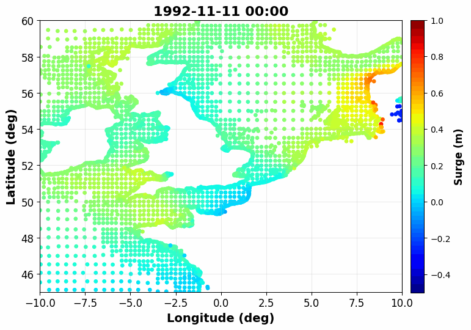

GTSM surge field (animated GIF) for the selected closure event

```
Animated GIF saved to output/master6_gtsm_surge.gif
```

## Figure - ERA5 Meteorological Maps

This figure shows ERA5 reanalysis pressure fields and wind vectors at 6 time steps around the closure event, showing the meteorological conditions that drove the surge.

```python
import matplotlib.gridspec as gridspec

int_skip = 3  # Skip every 3rd grid point for wind vectors

# Prepare data for all time steps
X_sub = X_MET[lon_idx[0]:lon_idx[-1]+1, lat_idx[0]:lat_idx[-1]+1]
Y_sub = Y_MET[lon_idx[0]:lon_idx[-1]+1, lat_idx[0]:lat_idx[-1]+1]
X_vec = X_MET[lon_idx[0]:lon_idx[-1]+1:int_skip, lat_idx[0]:lat_idx[-1]+1:int_skip]
Y_vec = Y_MET[lon_idx[0]:lon_idx[-1]+1:int_skip, lat_idx[0]:lat_idx[-1]+1:int_skip]

# Create figure with 2x3 grid + colorbar
fig = plt.figure(figsize=(16, 10))
gs = gridspec.GridSpec(2, 4, width_ratios=[1, 1, 1, 0.06], wspace=0.3, hspace=0.25)
axes = [fig.add_subplot(gs[i // 3, i % 3]) for i in range(6)]

# Plot each time step
ims = []
for i, t_idx in enumerate(t_met):
    ax = axes[i]

    # Get data for this time step
    P_sub = P_MET[lon_idx[0]:lon_idx[-1]+1, lat_idx[0]:lat_idx[-1]+1, t_idx] / 100
    U_vec = U_MET[lon_idx[0]:lon_idx[-1]+1:int_skip, lat_idx[0]:lat_idx[-1]+1:int_skip, t_idx]
    V_vec = V_MET[lon_idx[0]:lon_idx[-1]+1:int_skip, lat_idx[0]:lat_idx[-1]+1:int_skip, t_idx]

    # Plot pressure field
    im = ax.pcolormesh(X_sub, Y_sub, P_sub, cmap='jet', shading='gouraud', vmin=967, vmax=1020)
    ims.append(im)

    # Plot wind vectors
    ax.quiver(X_vec, Y_vec, U_vec, V_vec, color='k', scale=300, width=0.002)

    # Formatting
    ax.set_xlim(xb_met)
    ax.set_ylim(yb_met)
    ax.set_aspect('equal')
    ax.grid(True, alpha=0.3)
    ax.tick_params(labelsize=12)
    ax.set_title(TS_MET[t_idx].strftime('%Y-%m-%d %H:%M'), fontweight='bold', fontsize=16)

    if i >= 3:  # Bottom row
        ax.set_xlabel('Longitude (deg)', fontweight='bold', fontsize=14)
    if i % 3 == 0:  # Left column
        ax.set_ylabel('Latitude (deg)', fontweight='bold', fontsize=14)

# Add vertical colorbar at far right
cbar_ax = fig.add_subplot(gs[:, 3])
cbar = plt.colorbar(ims[0], cax=cbar_ax, orientation='vertical')
cbar.set_label('Pressure (hPa)', fontweight='bold', fontsize=14)
cbar.ax.tick_params(labelsize=12)

plt.tight_layout(rect=[0, 0, 0.97, 1])  # Leave space for colorbar
plt.show()

# Save figure
fig_file = os.path.join(output_dir, 'master6_era5_meteorology.png')
plt.savefig(fig_file, dpi=150, bbox_inches='tight')
print(f"\nFigure saved to {fig_file}")
```

[figure not shown]

ERA5 reanalysis pressure and wind fields at 6 time steps around the closure event

```
Figure saved to output/master6_era5_meteorology.png
```

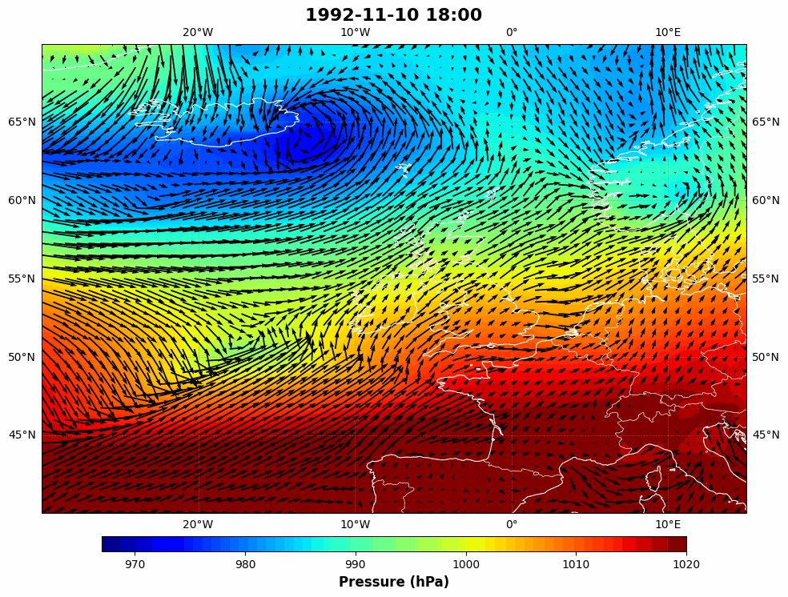

ERA5 pressure and wind field (animated GIF) for the selected closure event

```
Animated GIF saved to output/master6_era5_meteorology.gif
```

## Summary

This comprehensive analysis provides detailed insight into the meteorological conditions of a chosen storm event:

- **Water level context**: Shows how observed water levels, predicted tides, and surge evolved around the closure event
- **Spatial surge patterns**: GTSM reanalysis shows how surge developed and propagated spatially at 6-hour intervals
- **Meteorological forcing**: ERA5 reanalysis shows the pressure patterns and wind fields that drove the surge at 6 time steps displayed in a faceted layout
- **Temporal evolution**: The 6 time steps capture the development, peak, and decay of the storm system

This multi-faceted view helps understand the physical processes that led to the barrier closure, from large-scale meteorological forcing to local surge development.